# income_RF

Faris Dzikrur R

22/08/2019

# Latar Belakang, masalah, tujuan, dan metode yang akan dipakai

Pada LBB kali ini, saya menggunakan data Adult Census Income yang berisikan laporan sensus Amerika Serikat pada tahun 1994. Data ini akan saya gunakan untuk memprediksi dan mengetahui karakteristik warga Amerika Serikat yang memiliki penghasilan **di atas USD 50.000**. Hasil prediksi tersebut dapat digunakan oleh para pengambil keputusan dan mereka yang bekerja di bidang marketing untuk mengetahui karakter-karakter warga yang memiliki penghasilan tertentu. Adapun data yang digunakan adalah data Adult Census Income yang bisa didapatkan di [UCI Machine Learning](https://archive.ics.uci.edu/ml/datasets/census+income)

Load library yang akan digunakan

Baca data pada object bernama adult, lalu kita lihat structure dan 6 observasi awal dari data.

```
'data.frame':   32561 obs. of  15 variables:
 $ age           : int  90 82 66 54 41 34 38 74 68 41 ...
 $ workclass     : Factor w/ 9 levels "?","Federal-gov",..: 1 5 1 5 5 5 5 8 2 5 ...
 $ fnlwgt        : int  77053 132870 186061 140359 264663 216864 150601 88638 422013 70037 ...
 $ education     : Factor w/ 16 levels "10th","11th",..: 12 12 16 6 16 12 1 11 12 16 ...
 $ education.num : int  9 9 10 4 10 9 6 16 9 10 ...
 $ marital.status: Factor w/ 7 levels "Divorced","Married-AF-spouse",..: 7 7 7 1 6 1 6 5 1 5 ...
 $ occupation    : Factor w/ 15 levels "?","Adm-clerical",..: 1 5 1 8 11 9 2 11 11 4 ...
 $ relationship  : Factor w/ 6 levels "Husband","Not-in-family",..: 2 2 5 5 4 5 5 3 2 5 ...
 $ race          : Factor w/ 5 levels "Amer-Indian-Eskimo",..: 5 5 3 5 5 5 5 5 5 5 ...
 $ sex           : Factor w/ 2 levels "Female","Male": 1 1 1 1 1 1 2 1 1 2 ...
 $ capital.gain  : int  0 0 0 0 0 0 0 0 0 0 ...
 $ capital.loss  : int  4356 4356 4356 3900 3900 3770 3770 3683 3683 3004 ...
 $ hours.per.week: int  40 18 40 40 40 45 40 20 40 60 ...
 $ native.country: Factor w/ 42 levels "?","Cambodia",..: 40 40 40 40 40 40 40 40 40 1 ...
 $ income        : Factor w/ 2 levels "<=50K",">50K": 1 1 1 1 1 1 1 2 1 2 ...
```

```
  age workclass fnlwgt    education education.num marital.status
1  90         ?  77053      HS-grad             9        Widowed
2  82   Private 132870      HS-grad             9        Widowed
3  66         ? 186061 Some-college            10        Widowed
4  54   Private 140359      7th-8th             4       Divorced
5  41   Private 264663 Some-college            10      Separated
         occupation  relationship  race    sex capital.gain capital.loss
1                 ? Not-in-family White Female            0         4356
2   Exec-managerial Not-in-family White Female            0         4356
3                 ?     Unmarried Black Female            0         4356
4 Machine-op-inspct     Unmarried White Female            0         3900
5    Prof-specialty     Own-child White Female            0         3900
  hours.per.week native.country income
1             40  United-States  <=50K
2             18  United-States  <=50K
3             40  United-States  <=50K
4             40  United-States  <=50K
5             40  United-States  <=50K
 [ reached 'max' / getOption("max.print") -- omitted 1 rows ]
```

```
               ?      Federal-gov        Local-gov     Never-worked
            1836              960             2093                7
         Private     Self-emp-inc Self-emp-not-inc        State-gov
           22696             1116             2541             1298
     Without-pay
              14
```

```
                ?      Adm-clerical      Armed-Forces      Craft-repair
                0              3770                 9              4099
  Exec-managerial   Farming-fishing Handlers-cleaners Machine-op-inspct
             4066               994              1370              2002
    Other-service   Priv-house-serv    Prof-specialty   Protective-serv
             3295               149              4140               649
            Sales      Tech-support  Transport-moving
             3650               928              1597
```

Lalu kita cek NA-nya

```
           age      workclass         fnlwgt      education  education.num
             0           1836              0              0              0
marital.status     occupation   relationship           race            sex
             0           1843              0              0              0
  capital.gain   capital.loss hours.per.week native.country         income
             0              0              0            583              0
```

```
[1] 5.638647
```

```
[1] 5.660146
```

Karena persentase NA dalam data berkisar di 5%, maka kita membuang NA-nya.

# Preprocessing dan Exploring Dataset

Selanjutnya, kita akan melihat lebih jauh variabel di dalam dataset ini, termasuk persebaran datanya dan apakah variabel tersebut memiliki variance yang tinggi ataukah tidak.

## Variabel Numerik

Kita akan memeriksa variabel numerik pada data ini.

### Capital Gain

Pada bagian ini, kami akan melihat variance dari capital gain dan capital loss.

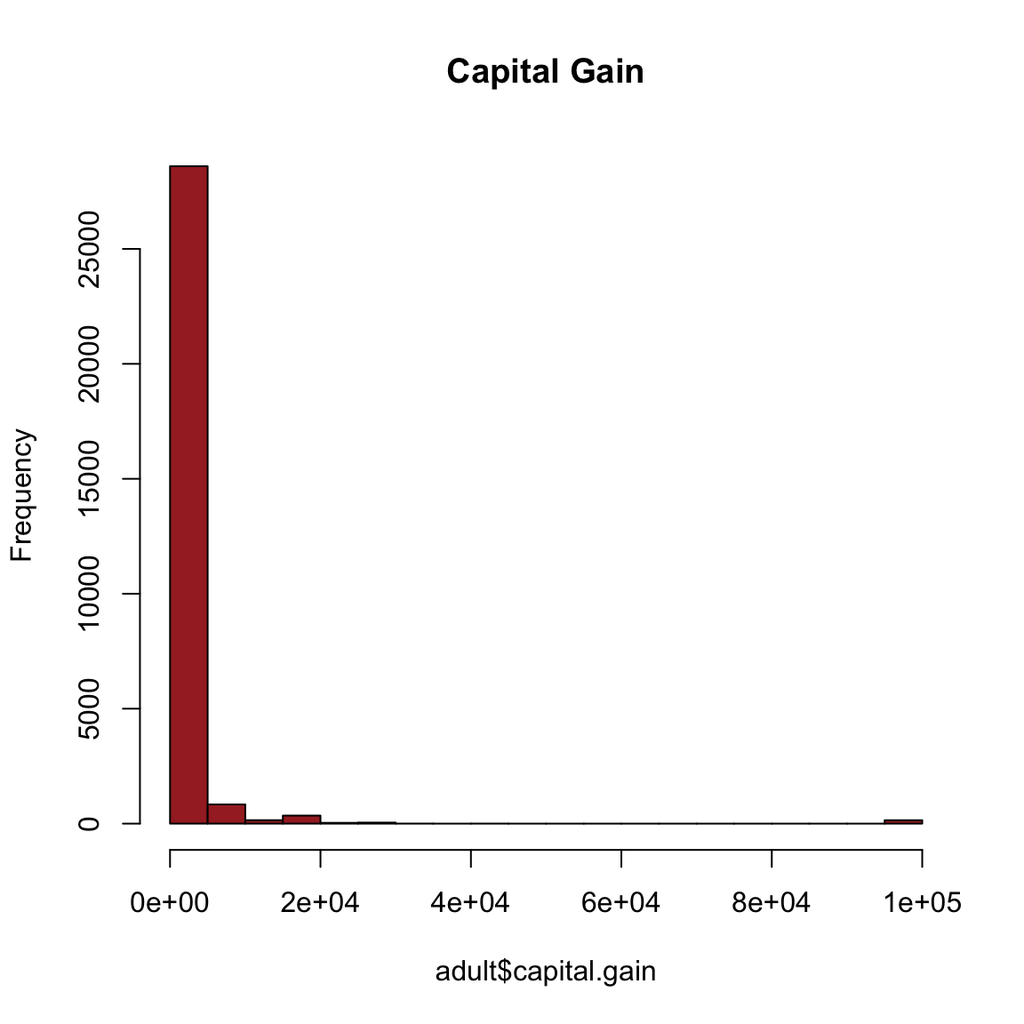

### Capital Loss

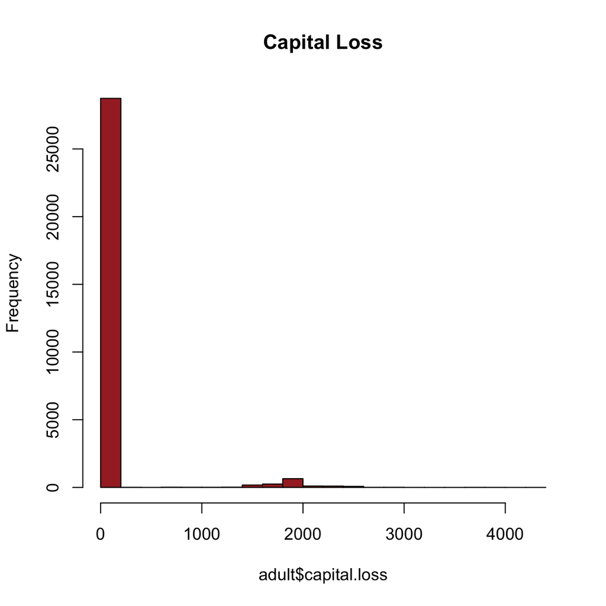

Kemudian diperiksa apakah ada warga yang mendapatkan capital gain dan capital loss di saat yang bersamaan.

```
[1] 0
```

Ternyata hasilnya 0, menandakan bahwa variabel capital gain dan capital loss adalah bersifat mutually exclusive (tak berhubungan) satu dengan yang lainnya. Karena keduanya pun juga mengukur besaran yang sama yaitu capital, maka untuk mensimplifikasi model, dibuatlah variabel baru bernama net.capital yang menggabungkan dua variabel tersebut.

### Net Capital Gain

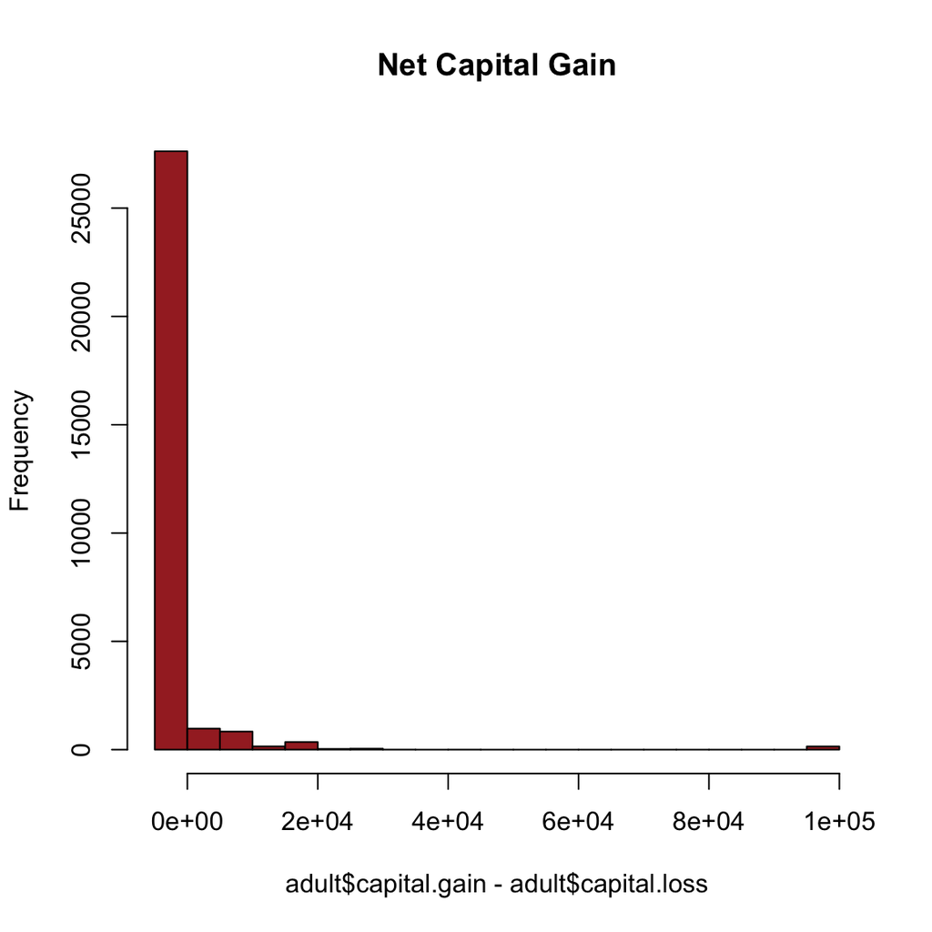

Buat variabel baru yaitu ‘net.capital’

Selanjutnya, kita akan memeriksa variabel kategorik pada data ini.

## Categorical Variable

### Workclass

Kita akan mengurangi kategori pada variabel workclass dengan cara menggabungkan beberapa kategori menjadi 1 kategori agar model menjadi lebih sederhana. Prosesnya seperti yang terlihat di bawah.

```
  Federal-gov       Private Self-employed        SL-gov    Unemployed
          943         22286          3573          3346            14
```

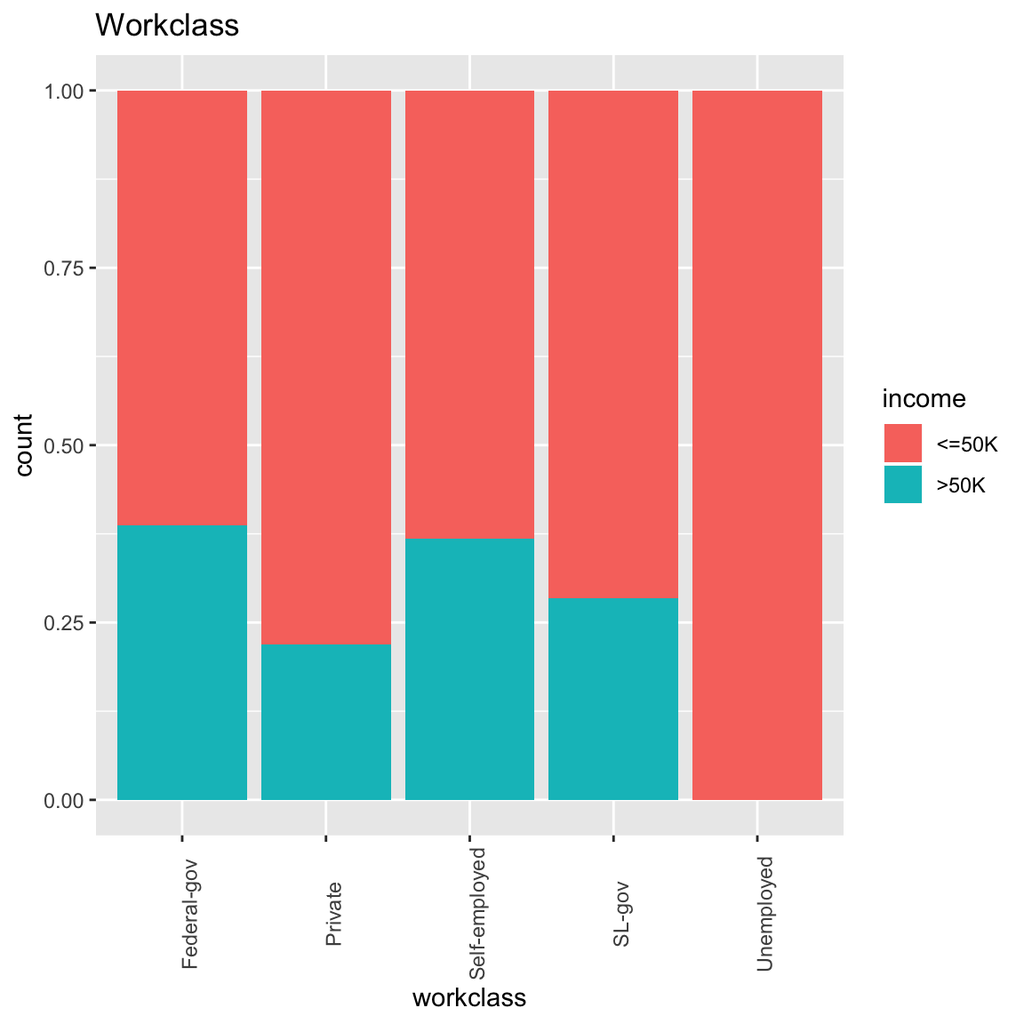

### Marital Status

Selanjutnya, kita menyederhanakan kategori pada ‘marital.status’ dengan menggabungkan beberapa kategori yang bisa digabungkan. Hasilnya seperti terlihat di bawah.

```
      Married Never-married   Not-Married
        14456          9726          5980
```

### Native Country

Pada variabel ‘native.country’, kita akan menggabungkan negara-negara dengan kontinen yang sama dan membuat kategori baru berdasarkan kontinennya. Ini dilakukan karena kategori pada variabel ini sangat banyak, yang dapat memberatkan model.

```
         Asia        Europe North America         Other South America
          634           493         28851            71           113
```

### Relationship

Menggabungkan wife dan husband dalam relationship menjadi spouse

```
The original levels Husband Not-in-family Other-relative Own-child Unmarried Wife
have been replaced by Not-in-family Other-relative Own-child Unmarried Spouse
```

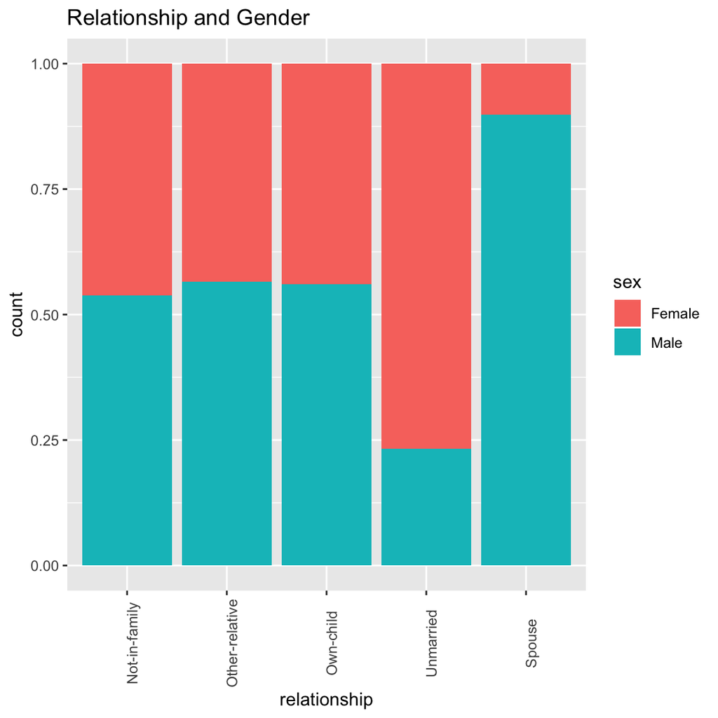

Selanjutnya, kita akan mengembalikan variabel ‘native.country’, ‘marital.status’, dan ‘workclass’ menjadi faktor kembali.

```
Observations: 30,162
Variables: 16
$ age            <int> 82, 54, 41, 34, 38, 74, 68, 45, 38, 52, 32, 46, 4…
$ workclass      <fct> Private, Private, Private, Private, Private, SL-g…
$ fnlwgt         <int> 132870, 140359, 264663, 216864, 150601, 88638, 42…
$ education      <fct> HS-grad, 7th-8th, Some-college, HS-grad, 10th, Do…
$ education.num  <int> 9, 4, 10, 9, 6, 16, 9, 16, 15, 13, 14, 15, 7, 14,…
$ marital.status <fct> Not-Married, Not-Married, Not-Married, Not-Marrie…
$ occupation     <fct> Exec-managerial, Machine-op-inspct, Prof-specialt…
$ relationship   <fct> Not-in-family, Unmarried, Own-child, Unmarried, U…
$ race           <fct> White, White, White, White, White, White, White, …
$ sex            <fct> Female, Female, Female, Female, Male, Female, Fem…
$ capital.gain   <int> 0, 0, 0, 0, 0, 0, 0, 0, 0, 0, 0, 0, 0, 0, 0, 0, 0…
$ capital.loss   <int> 4356, 3900, 3900, 3770, 3770, 3683, 3683, 3004, 2…
$ hours.per.week <int> 18, 40, 40, 45, 40, 20, 40, 35, 45, 20, 55, 40, 7…
$ native.country <fct> North America, North America, North America, Nort…
$ income         <fct> <=50K, <=50K, <=50K, <=50K, <=50K, >50K, <=50K, >…
$ net.capital    <int> -4356, -3900, -3900, -3770, -3770, -3683, -3683, …
```

Kemudian, dilakukan pengeliminasian variabel-variabel yang memiliki variance kecil, agar model menjadi lebih akurat. Kita juga akan melakukan eliminasi terhadap variabel ‘fnlwgt’ karena tidak relevan.

```
Observations: 30,162
Variables: 12
$ age            <int> 82, 54, 41, 34, 38, 74, 68, 45, 38, 52, 32, 46, 4…
$ workclass      <fct> Private, Private, Private, Private, Private, SL-g…
$ fnlwgt         <int> 132870, 140359, 264663, 216864, 150601, 88638, 42…
$ education      <fct> HS-grad, 7th-8th, Some-college, HS-grad, 10th, Do…
$ education.num  <int> 9, 4, 10, 9, 6, 16, 9, 16, 15, 13, 14, 15, 7, 14,…
$ marital.status <fct> Not-Married, Not-Married, Not-Married, Not-Marrie…
$ occupation     <fct> Exec-managerial, Machine-op-inspct, Prof-specialt…
$ relationship   <fct> Not-in-family, Unmarried, Own-child, Unmarried, U…
$ race           <fct> White, White, White, White, White, White, White, …
$ sex            <fct> Female, Female, Female, Female, Male, Female, Fem…
$ hours.per.week <int> 18, 40, 40, 45, 40, 20, 40, 35, 45, 20, 55, 40, 7…
$ income         <fct> <=50K, <=50K, <=50K, <=50K, <=50K, >50K, <=50K, >…
```

```
Observations: 30,162
Variables: 11
$ age            <int> 82, 54, 41, 34, 38, 74, 68, 45, 38, 52, 32, 46, 4…
$ workclass      <fct> Private, Private, Private, Private, Private, SL-g…
$ education      <fct> HS-grad, 7th-8th, Some-college, HS-grad, 10th, Do…
$ education.num  <int> 9, 4, 10, 9, 6, 16, 9, 16, 15, 13, 14, 15, 7, 14,…
$ marital.status <fct> Not-Married, Not-Married, Not-Married, Not-Marrie…
$ occupation     <fct> Exec-managerial, Machine-op-inspct, Prof-specialt…
$ relationship   <fct> Not-in-family, Unmarried, Own-child, Unmarried, U…
$ race           <fct> White, White, White, White, White, White, White, …
$ sex            <fct> Female, Female, Female, Female, Male, Female, Fem…
$ hours.per.week <int> 18, 40, 40, 45, 40, 20, 40, 35, 45, 20, 55, 40, 7…
$ income         <fct> <=50K, <=50K, <=50K, <=50K, <=50K, >50K, <=50K, >…
```

Ternyata, ada beberapa variabel yang terleminasi, seperti net.capital dan native.country yang memang memiliki variansi yang sedikit, dan hanya terpusat pada satu titik saja, seperti yang dijelaskan di atas. Pengeliminasian variabel 0 sebenarnya bisa dilakukan di awal, namun penulis ingin menunjukkan terlebih dahulu proses penggabungan kategori dan distribusi data pada tiap variabel.

# Cross Validation

# Model

## Model Decision Tree

Metode Pertama

Dilakukan pembuat model decision tree menggunakan function ‘ctree()’ lalu plot modelnya. Dari gambar di bawah terlihat bahwa model decision tree masih sangat kompleks dikarenakan banyaknya variabel dan kategori.

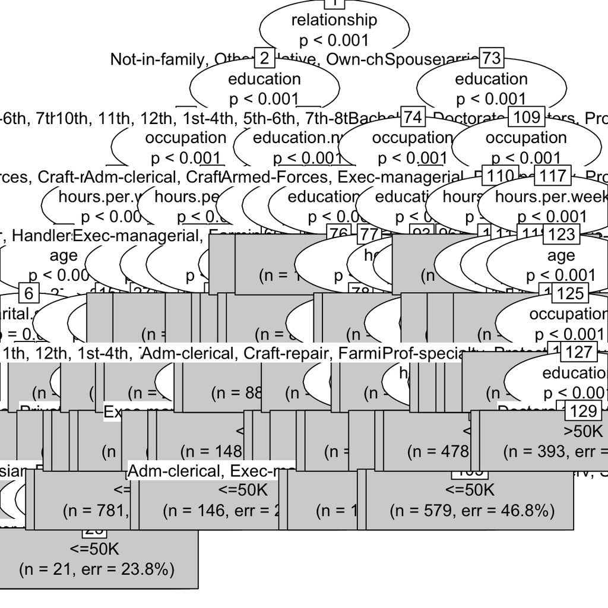

Kemudian dilakukan prediksi model menggunakan data train dan data test.

Dilanjutkan dengan mengeluarkan hasil confusion matrix dan membandingkan antara data train dan data test. Dari hasil di bawah, tampak bahwa akurasi sudah berada di angka 83% yang menandakan bahwa model sudah cukup baik. Perbedaan akurasi di antara data train dan data test juga kecil yang berarti bahwa model sudah fit.

```
Confusion Matrix and Statistics

          Reference
Prediction <=50K  >50K
     <=50K 16490  2325
     >50K   1659  3655

               Accuracy : 0.8349
                 95% CI : (0.8301, 0.8396)
    No Information Rate : 0.7522
    P-Value [Acc > NIR] : < 2.2e-16

                  Kappa : 0.54

 Mcnemar's Test P-Value : < 2.2e-16

            Sensitivity : 0.6112
            Specificity : 0.9086
         Pos Pred Value : 0.6878
         Neg Pred Value : 0.8764
             Prevalence : 0.2478
         Detection Rate : 0.1515
   Detection Prevalence : 0.2202
      Balanced Accuracy : 0.7599

       'Positive' Class : >50K
```

```
Confusion Matrix and Statistics

          Reference
Prediction <=50K >50K
     <=50K  4064  602
     >50K    441  926

               Accuracy : 0.8271
                 95% CI : (0.8173, 0.8366)
    No Information Rate : 0.7467
    P-Value [Acc > NIR] : < 2.2e-16

                  Kappa : 0.5265

 Mcnemar's Test P-Value : 7.261e-07

            Sensitivity : 0.6060
            Specificity : 0.9021
         Pos Pred Value : 0.6774
         Neg Pred Value : 0.8710
             Prevalence : 0.2533
         Detection Rate : 0.1535
   Detection Prevalence : 0.2266
      Balanced Accuracy : 0.7541

       'Positive' Class : >50K
```

Kemudian, dilakukan prunning untuk menyederhanakan node/batang pohon yang kita buat.

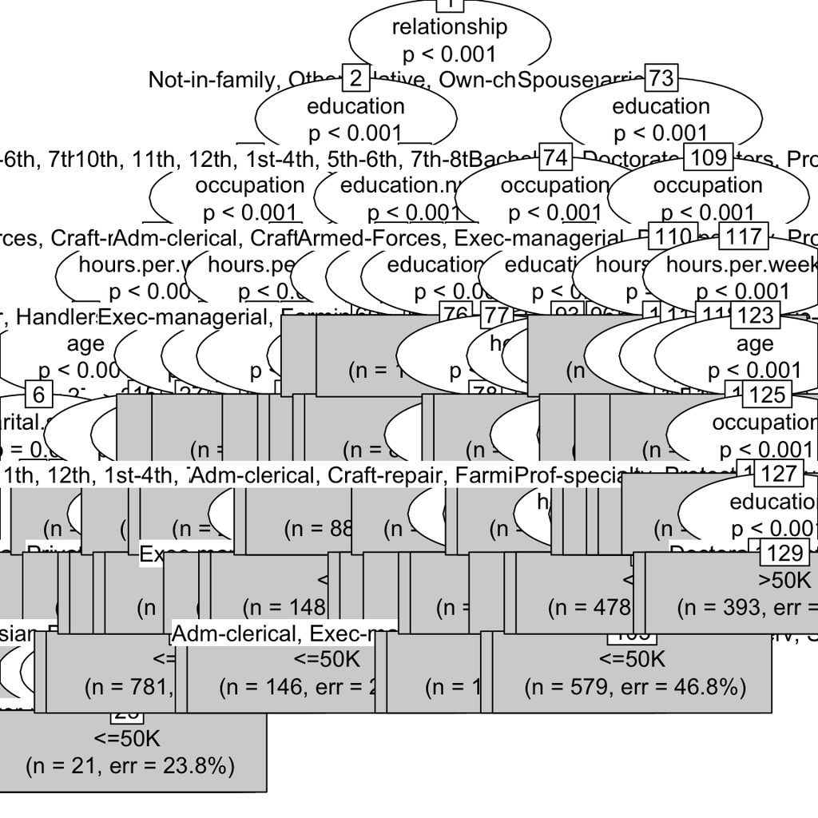

Dapat pula dilakukan evaluasi model yang lain menggunakan ROC dan AUC. ROC dilakukan dengan melakukan plot antara true positive rate dan false positive rate.

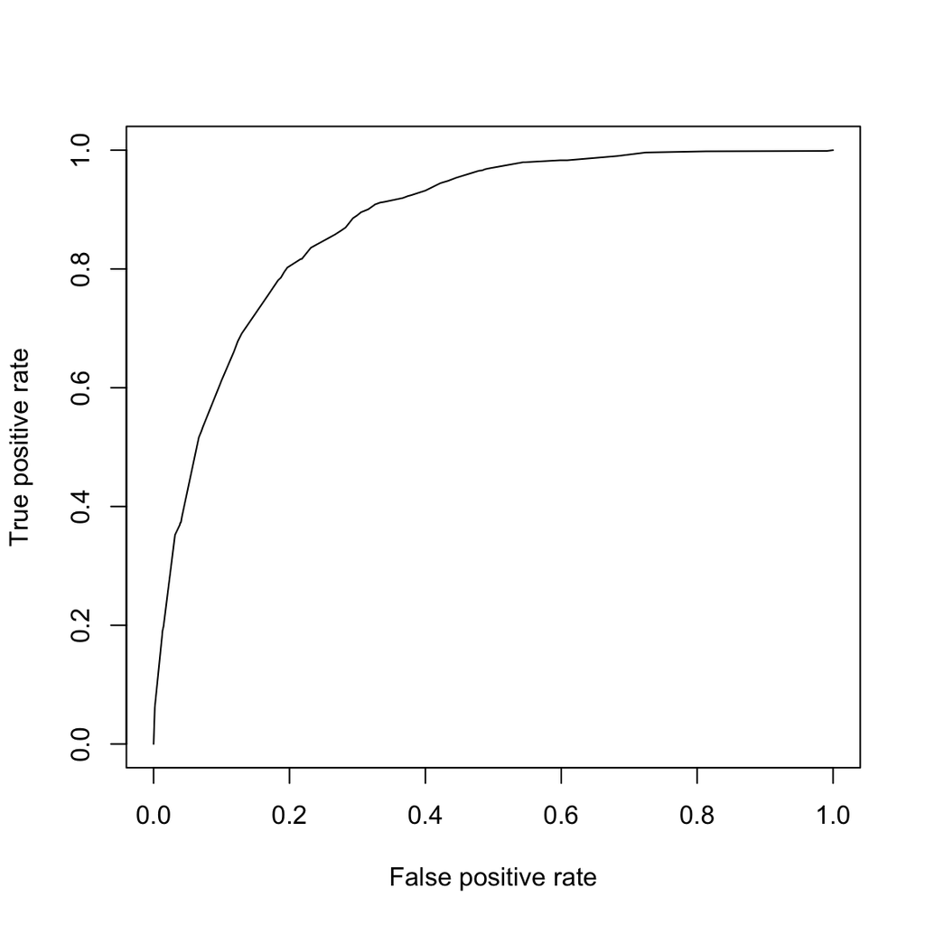

```
[1] 0.8795902
```

Tampak bahwa nilai auc adalah 87%, lebih tinggi daripada nilai akurasi yang sebesar 83%.

Metode kedua

Model decision tree ini menggunakan library rpart dan rattle. Metode ini menghasilkan pohon yang lebih sederhana tanpa harus dilakukan prunning terlebih dahulu.

Pertama kita membuat model decision tree

Lalu, model tersebut diplot.

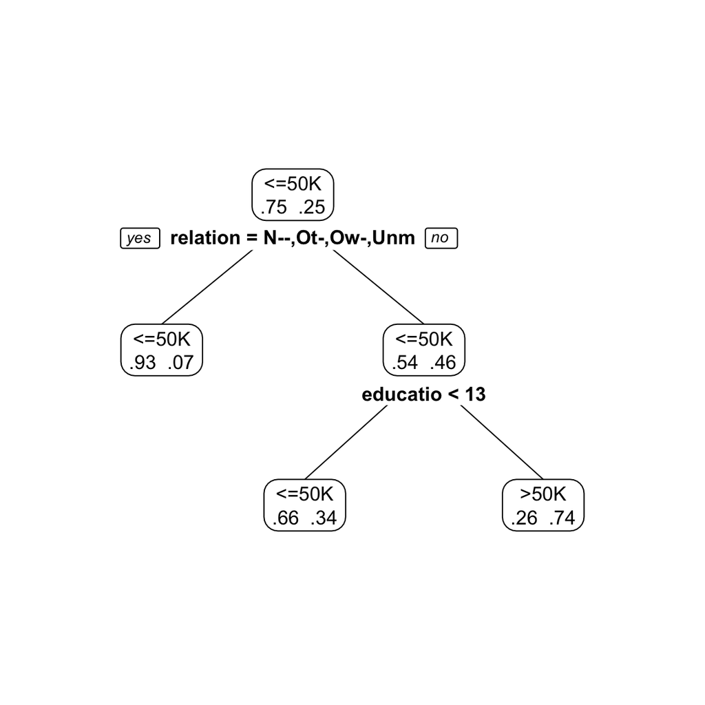

Tampak bahwa relationship merupakan variabel yang paling penting dalam melakukan prediksi menggunakan decision tree.

```
 Rule number: 7 [income=>50K cover=3298 (14%) prob=0.74]
   relationship=Spouse
   education.num>=12.5

 Rule number: 6 [income=<=50K cover=7787 (32%) prob=0.34]
   relationship=Spouse
   education.num< 12.5

 Rule number: 2 [income=<=50K cover=13044 (54%) prob=0.07]
   relationship=Not-in-family,Other-relative,Own-child,Unmarried
```

```
 Accuracy
0.8093817
```

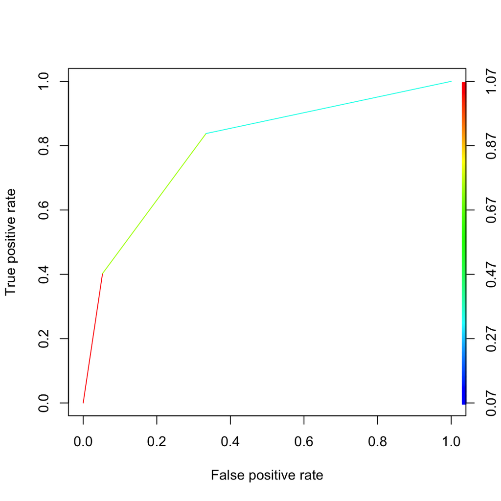

```
[[1]]
[1] 0.7970731
```

## Naive Bayes

Penulis akan coba membuat model dari data ini menggunakan metode Naive Bayes. Metode ini lebih bagus digunakan pada variabel bertipe numerik, namun dapat pula digunakan pada variabel kategorik, dengan konsekuensi berkurangnya akurasi model. Pada LBB ini, penulis akan memasukkan pula variabel kategori untuk memeriksa dan membandingkan tingkat akurasinya dengan metode lain. Di bawah ini adalah proses pembuatan model, prediksi, dan perbandingan confusion matrix antara data train dengan data test.

```
Confusion Matrix and Statistics

          Reference
Prediction <=50K >50K
     <=50K  3702  398
     >50K    803 1130

               Accuracy : 0.8009
                 95% CI : (0.7906, 0.8109)
    No Information Rate : 0.7467
    P-Value [Acc > NIR] : < 2.2e-16

                  Kappa : 0.5161

 Mcnemar's Test P-Value : < 2.2e-16

            Sensitivity : 0.7395
            Specificity : 0.8218
         Pos Pred Value : 0.5846
         Neg Pred Value : 0.9029
             Prevalence : 0.2533
         Detection Rate : 0.1873
   Detection Prevalence : 0.3204
      Balanced Accuracy : 0.7806

       'Positive' Class : >50K
```

```
Confusion Matrix and Statistics

          Reference
Prediction <=50K  >50K
     <=50K 15076  1509
     >50K   3073  4471

               Accuracy : 0.8101
                 95% CI : (0.8051, 0.815)
    No Information Rate : 0.7522
    P-Value [Acc > NIR] : < 2.2e-16

                  Kappa : 0.5317

 Mcnemar's Test P-Value : < 2.2e-16

            Sensitivity : 0.7477
            Specificity : 0.8307
         Pos Pred Value : 0.5927
         Neg Pred Value : 0.9090
             Prevalence : 0.2478
         Detection Rate : 0.1853
   Detection Prevalence : 0.3127
      Balanced Accuracy : 0.7892

       'Positive' Class : >50K
```

Dari hasil di atas, kita dapat lihat bahwa tidak terjadi over fitting pada model dikarenakan akurasi data train kurang lebih sama dengan akurasi data test.

Selanjutnya, hasil prediksi confusion matrix diassign dalam satu object bernama ‘nbaccu’ agar dapat diplot perbandingannya dengan metode lain.

```
 Accuracy
0.8009282
```

Dilakukan pula evaluasi menggunakan ROC.

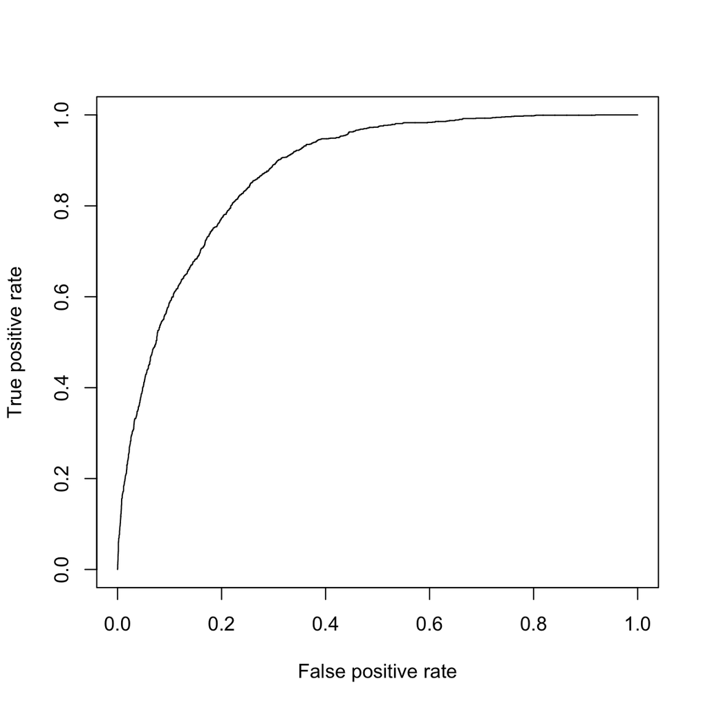

Tampak di bawah bahwa hasil akurasi menggunakan AUC lebih tinggi dibandingkan confusion matrix, yaitu sebesar 0.88%.

```
[1] 0.8750971
```

## Random Forest

Metode Pertama

Penulis menggunakan library ‘randomForest’

Dibuat model menggunakan data train dan prediksi menggunakan data test.

```
Call:
 randomForest(formula = income ~ ., data = train_adult, importance = TRUE)
               Type of random forest: classification
                     Number of trees: 500
No. of variables tried at each split: 3

        OOB estimate of  error rate: 16.53%
Confusion matrix:
      <=50K >50K class.error
<=50K 16562 1587  0.08744283
>50K   2401 3579  0.40150502
```

Selanjutnya kita akan melakukan plot pada OOB.

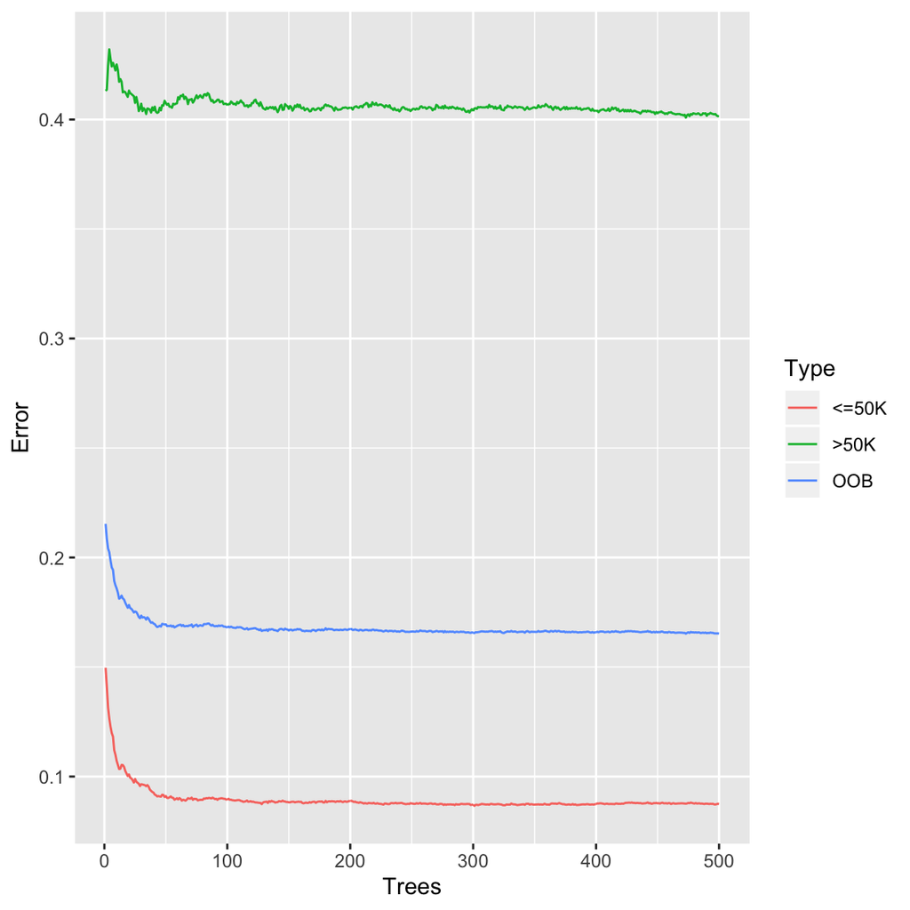

Pada grafik di atas, garis hijau menunjukkan rasio eror ketika mengklasifikasi >50K, garis merah menunjukkan rasio eror ketika mengklasifikasi <=50K, dan garis biru menunjukkan rasio eror OOB secara keseluruhan. Secara umum, kita lihat bahwa rasio eror menurun ketika jumlah pohon bertambah.

```
 [1] 0.1737743 0.1611753 0.1642008 0.1709561 0.1780430 0.1838866 0.1863732
 [8] 0.1876580 0.1884040 0.1888184
```

Diketahui dari hasil mtry di atas bahwa OOB terendah didapat ketika mtry=2.

Kemudian hasil akurasi prediksi confusion matrix diassign pada object ‘rfAccu’. Akurasi pada model ini pada angka 83%

```
 Accuracy
0.8287751
```

Dari model ini kita dapat melihat mana saja variabel-variabel yang penting dengan menggunakan ‘varImpPLot()’

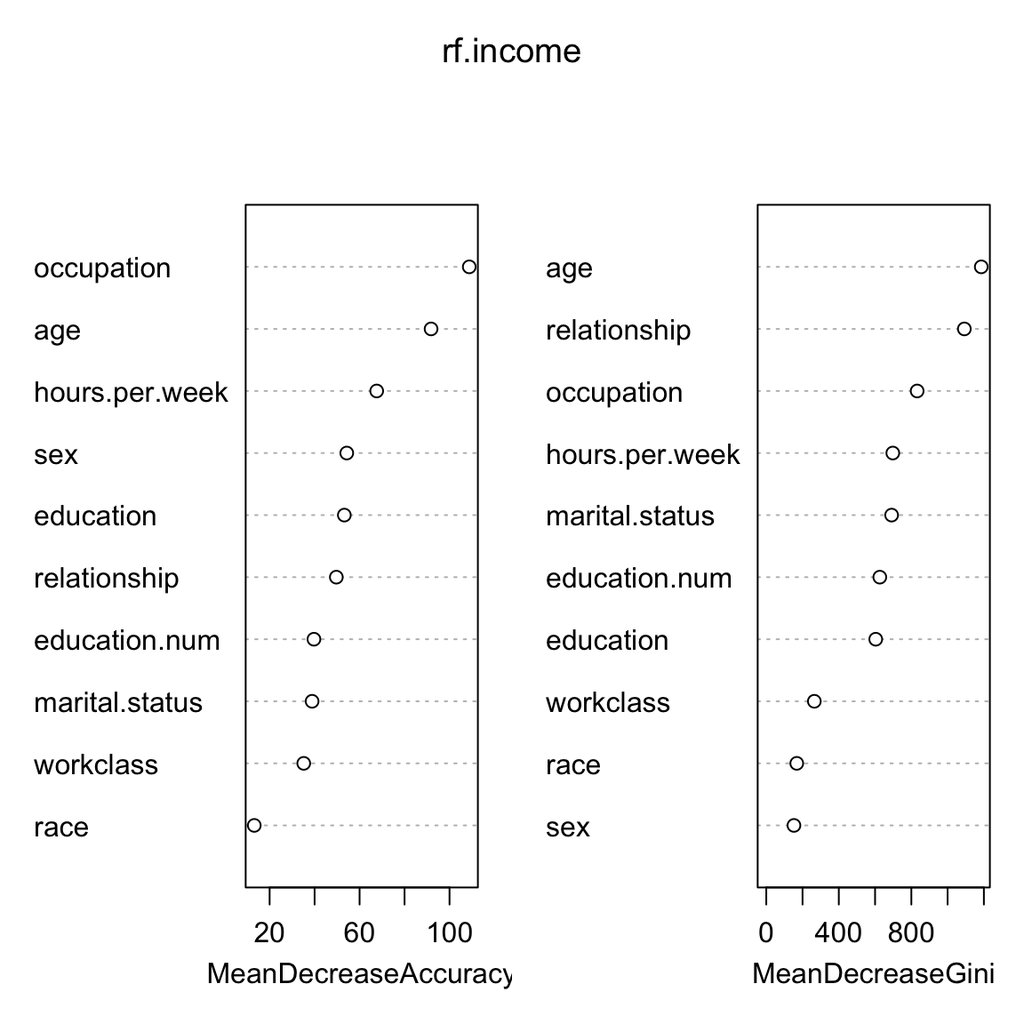

Dilakukan pula evaluasi menggunakan metode ROC dan AUC dan

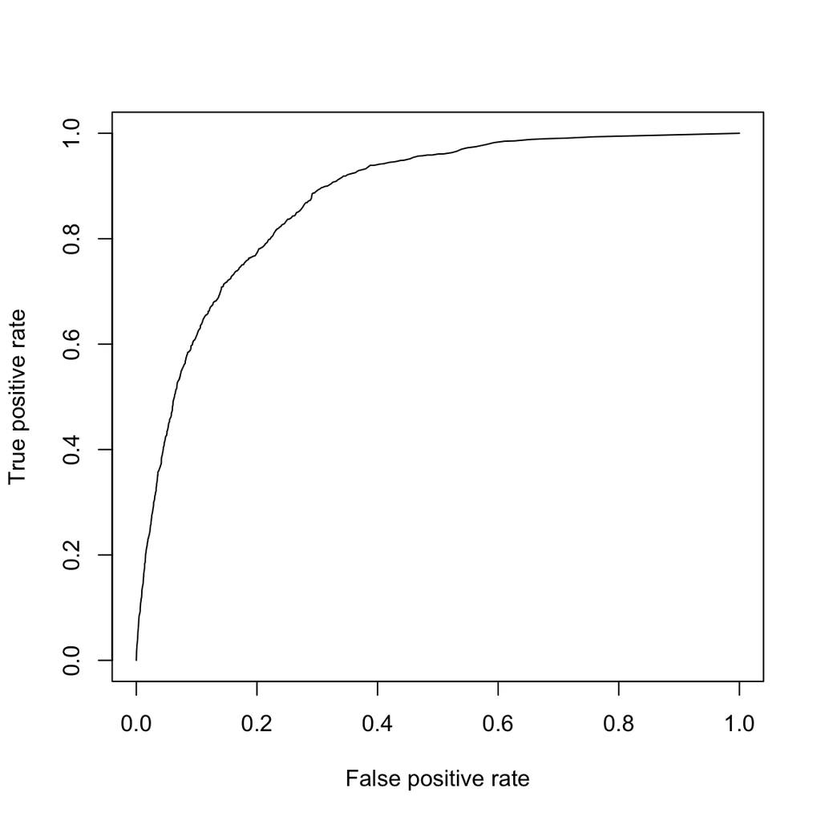

Tampak dari hasil AUC di bawah bahwa akurasinya berada pada angka 87%, lebih tinggi dari akurasi pada confusionmatrix.

```
[1] 0.8755788
```

# Performance Comparison

Pada bagian akhir ini, kita akan membuat plot untuk membandingkan nilai akurasi yang didapatkan dari model menggunakan Naive Bayes, Decision Tree, dan Random Forest. Tampak bahwa Random Forest memiliki nilai akurasi tertinggi, diikuti dengan Decision Tree dan Naive Bayes. Sudah dapat diduga bahwa Naive Bayes memiliki tingkat akurasi terendah karena kita memasukkan pula variabel kategori ke dalam model Naive Bayes.

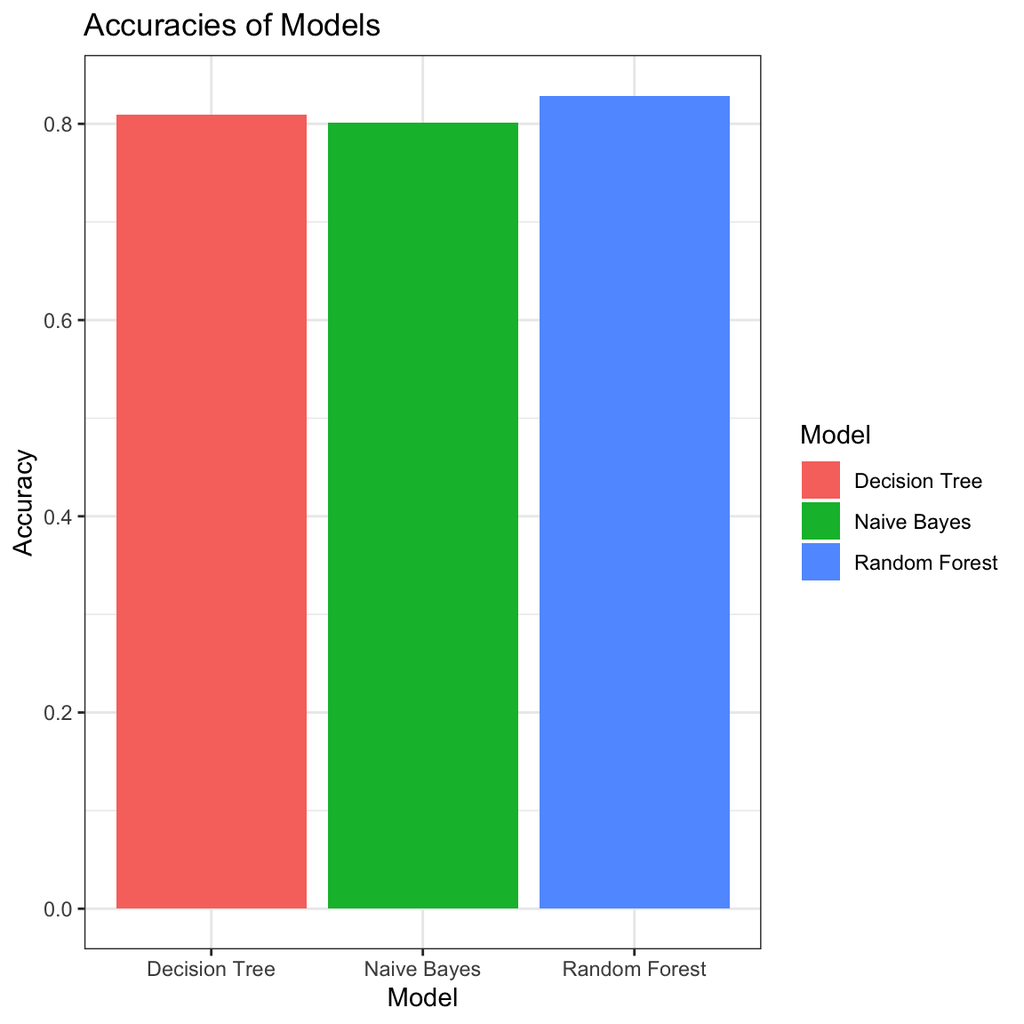